# May institute Data visualization module: Hands-on 1

Ting Huang and Dan Guo

May 8, 2017

# Objectives

- Creating a new RStudio project
- Reading in data
- Data manipulation
- Visualizing data
- Saving your work

Part 1 and 2 are adapted from the material of May Institute [Beginner’s statistics in R](https://github.com/MayInstitute/MayInstitute2017/blob/master/Program3_Intro%20stat%20in%20R/01-rstats.Rmd).

# 1. Create a new Rstudio project

It is good practice to keep a set of related data, analyses, and text self-contained in a single folder, called the **working directory**. All of the scripts within this folder can then use *relative paths* to files that indicate where inside the project a file is located (as opposed to absolute paths, which point to where a file is on a specific computer). Working this way makes it a lot easier to move your project around on your computer and share it with others without worrying about whether or not the underlying scripts will still work.

Below, we will go through the steps for creating an “R Project” for this tutorial.

- Under the `File` menu, click on `New project`, choose `New directory`, then `Empty project`
- Enter a name for this new folder (or “directory”), and choose a convenient location for it. This will be your **working directory** for the rest of the day (e.g., `datavis`)
- Click on `Create project`
- Create a new R script in your working directory, calling it e.g., `part1-script.R`.

# 2. Reading in data

The file we’ll be reading in is a public protein quantification dataset (Reference: http://onlinelibrary.wiley.com/doi/10.15252/emmm.201404873/abstract) that has been summarized by each run and protein with MSstats. Its experimental design is shown below:

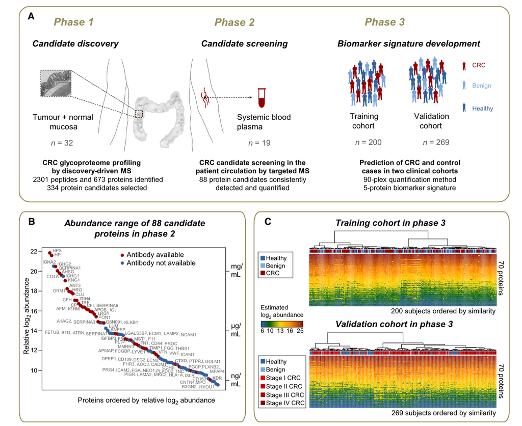

We will practice with it throughout the whole module.

```r
CRC <- read.csv("./data/CRC_train.csv")
```

# 3. Data exploration

Let’s explore some basic properties of our dataset. Go to the RStudio Environment pane and double click the `CRC` entry.

`class` shows the type of a variable, in this case a data.frame

```r
class(CRC)
```

```
## [1] "data.frame"
```

`dim` shows the dimension of a data.frame, which are the number of rows and the number of columns

```r
dim(CRC)
```

```
## [1] 200  79
```

```r
str(CRC)
```

`colnames` is short for column names.

```r
colnames(CRC)
```

`head` shows the first 6 rows of data. Try `tail` to show the last 6 rows of data.

```r
head(CRC)
```

Let’s explore the type of every column/variable and a summary for the value range for every column.

```r
summary(CRC)
```

```r
unique(CRC[, 'Sub_group'])
```

```
## [1] CRC     Benign  Healthy
## Levels: Benign CRC Healthy
```

```r
unique(CRC[, 79])
```

```
## [1] CRC     Benign  Healthy
## Levels: Benign CRC Healthy
```

We may be interested in working from here on only with data for proteins TIMP1 and SERPINA3.

```r
CRC.twopro <- CRC[,c('TIMP1', 'SERPINA3')]
```

We may be also interested in only CRC data.

```r
CRC_tumor <- CRC[CRC$Sub_group=="CRC",]
```